# Projecte Sèries Temporals

Ara estimem el segon model:$ARIMA(0,1,2)(0,1,1)_{12}$

```r
(mod2.lin=arima(d1d12lnserie.lin,order=c(0,0,2),seasonal=list(order=c(0,0,1),period=12)))
```

```
Call:
arima(x = d1d12lnserie.lin, order = c(0, 0, 2), seasonal = list(order = c(0,
    0, 1), period = 12))

Coefficients:
          ma1      ma2     sma1  intercept
      -0.2952  -0.3007  -0.8071      1e-04
s.e.   0.0541   0.0578   0.0455      2e-04

sigma^2 estimated as 0.00117:  log likelihood = 648.88,  aic = -1287.76
```

Quan estimem el model per a la sèrie transformada veiem que la mitjana no és significativa, per tant ho tornem a fer per la sèrie original

```r
(mod2.lin=arima(lnserie.lin,order=c(0,1,2),seasonal=list(order=c(0,1,1),period=12)))
```

```
Call:
arima(x = lnserie.lin, order = c(0, 1, 2), seasonal = list(order = c(0, 1, 1),
    period = 12))

Coefficients:
          ma1     ma2     sma1
      -0.2931  -0.295  -0.7993
s.e.   0.0543   0.057   0.0442

sigma^2 estimated as 0.001174:  log likelihood = 648.57,  aic = -1289.13
```

Comprovem que tots els coeficients són significatius i per tant no hem d’eliminar cap.

Ara comprovem els residus en cada model.

*Model 1:* $ARIMA(2,1,0)(3,1,0)_{12}$

```r
resi1.lin=resid(mod1.lin)
```

El primer que mirem és si la variància és constant.

Plot dels residus:

```r
plot(resi1.lin)
abline(h=0)
```

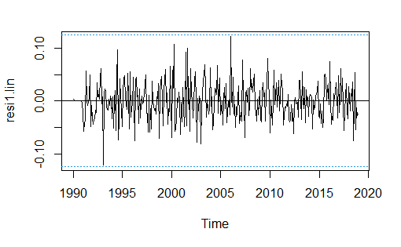

```r
abline(h=c(-3*sd(resi1),3*sd(resi1)),lty=3,col=4)
```

Marquem les línies de referència i veiem com pràcticament tots els residus es troben dins d’aquest interval. El 99.7% dels residus hauria de trobar-se dins de l’interval, cosa que podem veure que passa en la nostra sèrie. No sobresurt cap valor ja que els atípics ja han sigut tractats.

Plot de l’arrel quadrada del valor absolut dels residus amb ajust suau:

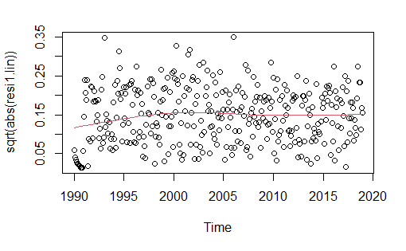

```r
scatter.smooth(sqrt(abs(resi1.lin)), lpars=list(col=2))
```

Amb aquest plot veiem l’evolució de l’estimació de la variança. Com la línia és aproximadament horitzontal, considerem que la variància si que és constant.

Ara mirem si podem considerar que els residus provenen d’una distribució normal.

Plot de Normalitat:

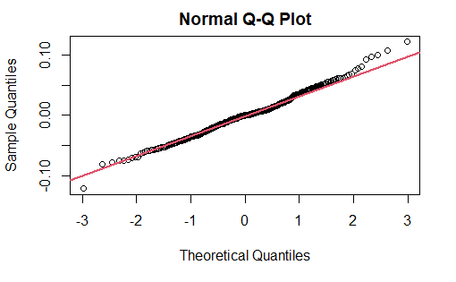

```r
qqnorm(resi1.lin)
qqline(resi1.lin,col=2,lwd=2)
```

Histograma amb la corba normal superposada:

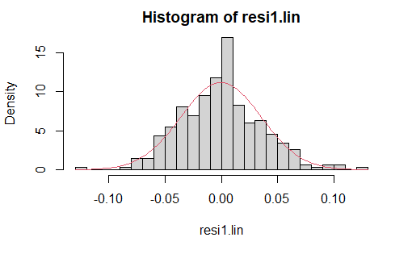

```r
hist(resi1.lin,breaks=20, freq=FALSE)
curve(dnorm(x, mean=mean(resi1.lin), sd=sd(resi1.lin)), col=2, add=T)
```

Test de Shapiro-Wilks, on la hipòtesi nul·la és que els residus segueixen una distribució normal:

```r
shapiro.test(resi1.lin)
```

```
    Shapiro-Wilk normality test

data:  resi1.lin
W = 0.99278, p-value = 0.09178
```

Amb totes aquestes dades concluïm que els residus si que provenen d’una distribució normal. En el plot de normalitat observem com les dades s’ajusten bastant a la línia de normalitat. Només es desvien una mica la cua superior. En l’histograma no sembla que s’ajusti del tot bé a la corba de normalitat, però, amb el test de normalitat de Shapiro-Wilks confirmem que els residus si que presenten normalitat, ja que el p-valor és major que 0.05, per tant acceptem la hipòtesi de normalitat.

A continuació, volem saber si podem considerar que els residus són independents.

Primer representem l’ACF i la PACF dels residus:

```r
par(mfrow=c(1,2))
acf(resi1.lin,ylim=c(-1,1),lag.max=60,col=c(2,rep(1,11)),lwd=2)
pacf(resi1.lin,ylim=c(-1,1),lag.max=60,col=c(rep(1,11),2),lwd=2)
```

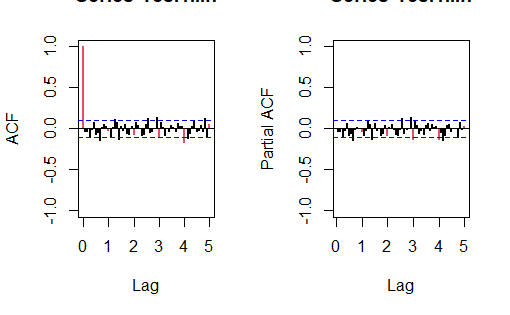

```r
par(mfrow=c(1,1))
```

Amb l’ACF i la PACF sembla que els residus no són independents, ja que hi ha una quantitat important de residus que es sobresurten de les bandes de confiança.

Per confirmar-ho, fem el test de Ljung-Box i representem els p-valors:

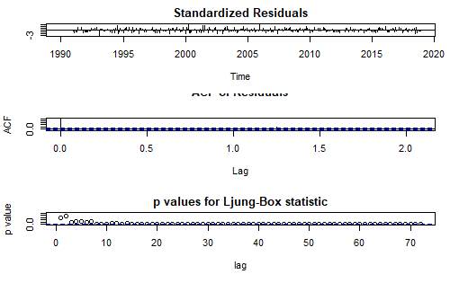

```r
tsdiag(mod1.lin,gof.lag=72)
```

Quan fem el test de Ljung-Box veiem com hi ha molts residus per sota del 0.05, per tant no podem considerar que els residus siguin independents (soroll blanc).

En resum, pel primer model considerem que els residus tenen variància constant i provenen d’una distribució normal, però no són independents, exactament igual que amb el model sense linealitzar.

**Model 2:** $ARIMA(0,1,2)(0,1,1)_{12}$

```r
resi2.lin=resid(mod2.lin)
```

El primer que mirem és si la variància és constant.

Plot dels residus:

```r
plot(resi2.lin)
abline(h=0)
```

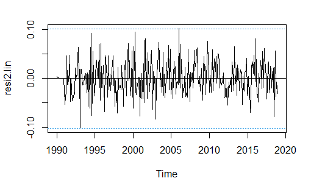

```r
abline(h=c(-3*sd(resi2.lin),3*sd(resi2.lin)),lty=3,col=4)
```

En aquest primer gràfic veiem com els valors dels residus es troben dins de les bandes de confiança. Hi un valor valors que sobresurten però considerem que són atípics causats per l’aleatorietat.

Plot de l’arrel quadrada del valor absolut dels residus amb ajust suau:

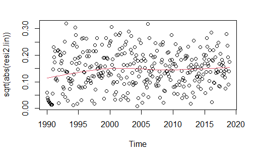

```r
scatter.smooth(sqrt(abs(resi2.lin)), lpars=list(col=2))
```

Amb aquest plot veiem l’evolució de l’estimació de la variança. Com la línia és aproximadament horitzontal, considerem que la variància si que és constant.

Ara mirem si podem considerar que els residus provenen d’una distribució normal.

Plot de Normalitat:

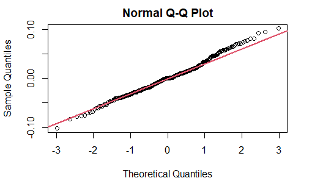

```r
qqnorm(resi2.lin)
qqline(resi2.lin,col=2,lwd=2)
```

Histograma amb la corba normal superposada:

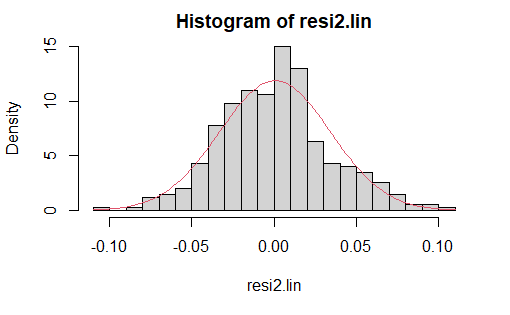

```r
hist(resi2.lin,breaks=20, freq=FALSE)
curve(dnorm(x, mean=mean(resi2.lin), sd=sd(resi2.lin)), col=2, add=T)
```

Test de Shapiro-Wilks, on la hipòtesi nul·la és que els residus segueixen una distribució normal:

```r
shapiro.test(resi2.lin)
```

```
    Shapiro-Wilk normality test

data:  resi2.lin
W = 0.99238, p-value = 0.07236
```

Amb aquestes dades concluïm que els residus si que provenen d’una distribució normal. En el plot de normalitat veiem com les dades s’ajusten bastant a la línia de normalitat. Només es desvien una mica les cues, el qual pot ser degut a atípics. L’histograma s’ajusta més o menys a la corba de normalitat. I amb el test de normalitat de Shapiro-Wilks podem confirmar que els residus si que presenten normalitat, ja que el p-valor és major que 0.05, per tant acceptem la hipòtesi de normalitat.

Per últim, volem saber si els residus són independents.

Primer representem l’ACF i la PACF dels residus:

```r
par(mfrow=c(1,2))
acf(resi2.lin,ylim=c(-1,1),lag.max=60,col=c(2,rep(1,11)),lwd=2)
pacf(resi2.lin,ylim=c(-1,1),lag.max=60,col=c(rep(1,11),2),lwd=2)
```

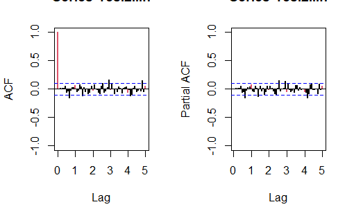

```r
par(mfrow=c(1,1))
```

Amb l’ACF i la PACF sembla que els residus no són independents, ja que hi ha una quantitat significant de residus que es sobresurten de les bandes de confiança.

Per confirmar-ho, fem el test de Ljung-Box i representem els p-valors:

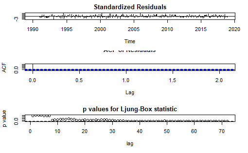

```r
tsdiag(mod2.lin,gof.lag=72)
```

Quan fem el test de Ljung-Box veiem com hi ha molts residus per sota del 0.05, per tant no podem considerar que els residus siguin independents (soroll blanc).

En resum, pel segon model concluïm que els residus tenen variància constant i provenen d’una distribució normal, però no són independents, igual que en el model 1 i que en els models sense linealitzar.

Ara portem a terme la validació **Model 1:** $ARIMA(2,1,0)(3,1,0)_{12}$ Ara volem veure si és estacionari i/o invertible busquem les arrels dels polinomis característics:

```r
Mod(polyroot(c(1,-mod1.lin$model$phi))) # part AR
```

```
 [1] 1.044191 1.044191 1.044191 1.044191 1.055776 1.044191
 [7] 1.055776 1.055776 1.044191 1.044191 1.044191 1.044191
[13] 1.055776 1.044191 1.044191 1.044191 1.044191 1.055776
[19] 1.044191 1.044191 1.055776 1.044191 1.044191 1.055776
[25] 1.044191 1.055776 1.055776 1.044191 1.055776 1.044191
[31] 1.044191 1.044191 1.044191 1.055776 1.055776 1.800919
[37] 1.044191 1.800919
```

```r
Mod(polyroot(c(1,mod1.lin$model$theta))) # part MA
```

```
numeric(0)
```

Finalment calculem les mesures d’adequació a les dades (AIC i BIC:

```r
AIC(mod1.lin)
```

```
[1] -1254.194
```

```r
BIC(mod1.lin)
```

```
[1] -1231.31
```

**Model 2:** $ARIMA(0,1,2)(0,1,1)_{12}$

Ara volem veure si és estacionari i/o invertible busquem les arrels dels polinomis característics:

```r
Mod(polyroot(c(1,-mod2.lin$model$phi))) # part AR
```

```
numeric(0)
```

```r
Mod(polyroot(c(1,mod2.lin$model$theta))) # part MA
```

```
 [1] 1.018843 1.018843 1.018843 1.018843 1.018843 1.018843
 [7] 1.018843 1.018843 1.018843 1.018843 1.018843 1.018843
[13] 1.410208 2.403497
```

Finalment calculem les mesures d’adequació a les dades (AIC i BIC:

```r
AIC(mod2.lin)
```

```
[1] -1289.133
```

```r
BIC(mod2.lin)
```

```
[1] -1273.876
```